# Custom Color Palette for ggplot2

Last updated 2020-12-29.

I’m describing customizing my own color palette for ggplot2. This is based off of [Creating corporate colour palettes for ggplot2](https://drsimonj.svbtle.com/creating-corporate-colour-palettes-for-ggplot2) by drsimonj.

First, find a bunch of colors that you like. [Canva](https://www.canva.com/) is a good place to go for inspiration; or, us this [tool from Adobe Color](https://color.adobe.com/create/image) that will extract colors from a photo you like. Then, there’s always [colorbrewer2](https://colorbrewer2.org/#type=sequential&scheme=BuGn&n=3).

*Note: In many cases, you can get away with using the `scale_color_manual()` and `scale_fill_manual()` functions directly within ggplot2. See [the docs](https://ggplot2.tidyverse.org/reference/scale_manual.html) for examples.*

Define colors

```r
rjfranssen_colors <- c(
  `ebony` = "#1E2225",
  `blue_grotto` = "#05263B",
  `charcoal` = "#43758A",
  `light_sea_green` = "#36B4AF",
  `pewter` = "#D3DADA",
  `carafe` = "#55423A",
  `goldenrod` = "#F1B416",
  `burnt_sienna` = "#E56A19",
  `crimson` = "#900000")
```

Function to extract colors as hex codes (source: [drsimonj](https://drsimonj.svbtle.com/creating-corporate-colour-palettes-for-ggplot2))

```r
rjfranssen_cols <- function(...) {
  cols <- c(...)

  if (is.null(cols))
    return (rjfranssen_colors)

  rjfranssen_colors[cols]
}
```

Examples of returning specific color codes. The `scales` package has a convenient `show_col()` function for this:

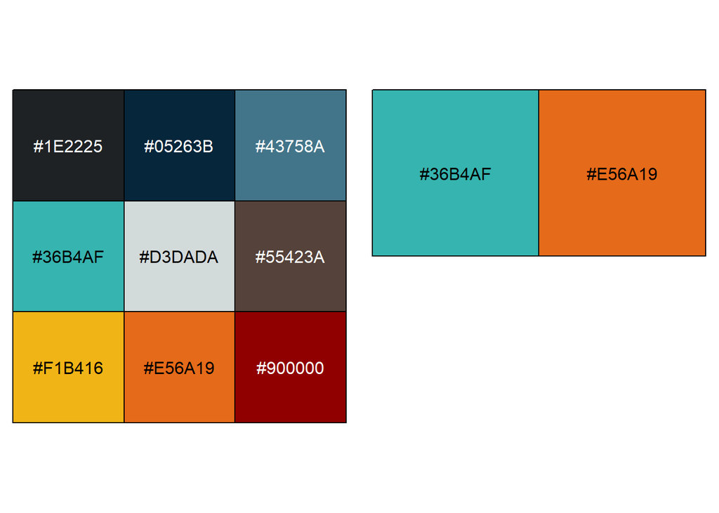

```r
library(scales)
library(dplyr)

par(mfrow=c(1,2))
rjfranssen_cols() %>% show_col()
rjfranssen_cols("light_sea_green", "burnt_sienna") %>% show_col()
```

Simply plot example.

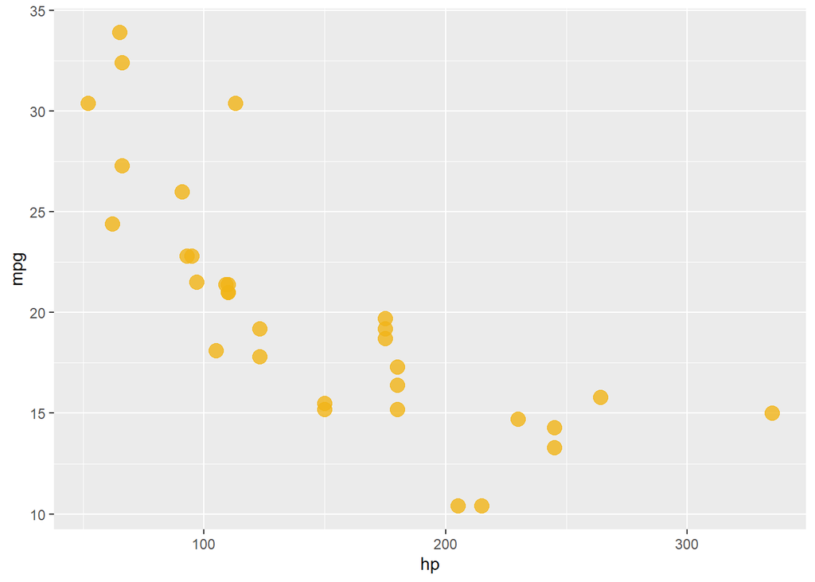

```r
ggplot(mtcars, aes(hp, mpg)) +
    geom_point(color = rjfranssen_cols("goldenrod"),
               size = 4, alpha = .8)
```

Now, combine sets of colors into individual palettes.

```r
rjfranssen_palettes <- list(

  `primary`  = rjfranssen_cols("ebony", "blue_grotto", "charcoal", "light_sea_green", "pewter"),

  `secondary`  = rjfranssen_cols("carafe", "goldenrod", "burnt_sienna", "crimson"),

  `all`   = rjfranssen_cols("ebony", "blue_grotto", "charcoal", "light_sea_green", "pewter", "carafe", "goldenrod", "burnt_sienna", "crimson")
)
```

Function to interpolate the palettes (source: [drsimonj](https://drsimonj.svbtle.com/creating-corporate-colour-palettes-for-ggplot2)). Option to padd additional arguments into `colorRampPallete()` like `alpha`.

```r
rjfranssen_pal <- function(palette = "main", reverse = FALSE, ...) {
  pal <- rjfranssen_palettes[[palette]]

  if (reverse) pal <- rev(pal)

  colorRampPalette(pal, ...)
}
```

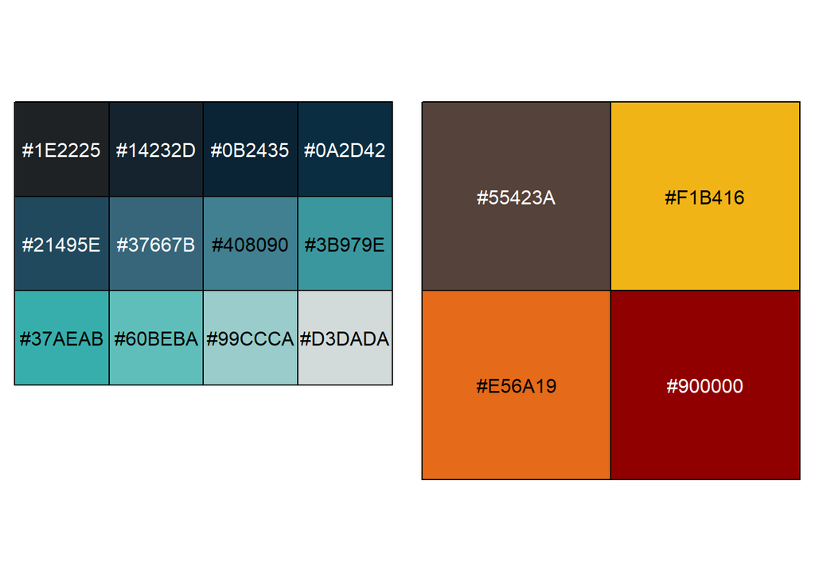

```r
par(mfrow=c(1,2))

rjfranssen_pal("primary")(12) %>% show_col()
rjfranssen_pal("secondary")(4) %>% show_col()
```

Everything that’s been up to this point is creating a storage places for favorite colors. Now, prepare some functions specifically for using with `ggplot`.

```r
scale_color_rjfranssen <- function(palette = "main",
           discrete = TRUE,
           reverse = FALSE,
           ...) {
    pal <- rjfranssen_pal(palette = palette, reverse = reverse)

    if (discrete) {
      discrete_scale("colour", paste0("rjfranssen_", palette), palette = pal, ...)
    } else {
      scale_color_gradientn(colours = pal(256), ...)
    }
}

scale_fill_rjfranssen <- function(palette = "main", discrete = TRUE, reverse = FALSE, ...) {
  pal <- rjfranssen_pal(palette = palette, reverse = reverse)

  if (discrete) {
    discrete_scale("fill", paste0("rjfranssen_", palette), palette = pal, ...)
  } else {
    scale_fill_gradientn(colours = pal(256), ...)
  }
}
```

Done - now plotting a few examples.

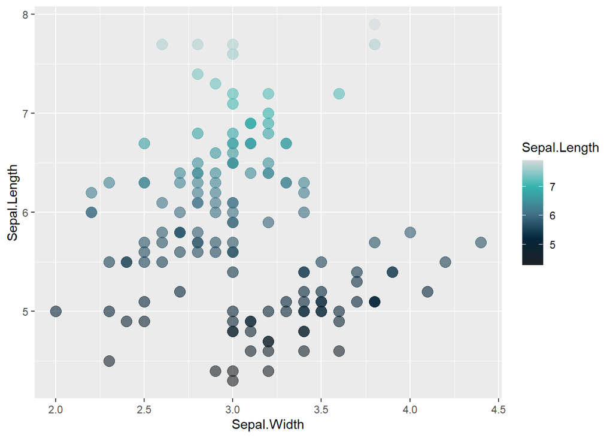

```r
ggplot(iris, aes(Sepal.Width, Sepal.Length, color = Sepal.Length)) +
    geom_point(size = 4, alpha = .6) +
    scale_color_rjfranssen(discrete = FALSE, palette = "primary")
```

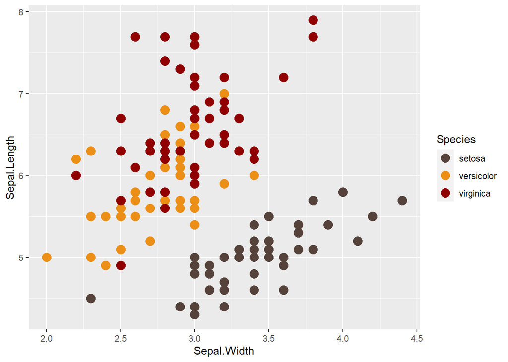

```r
ggplot(iris, aes(Sepal.Width, Sepal.Length, color = Species)) +
    geom_point(size = 4) +
    scale_color_rjfranssen("secondary")
```

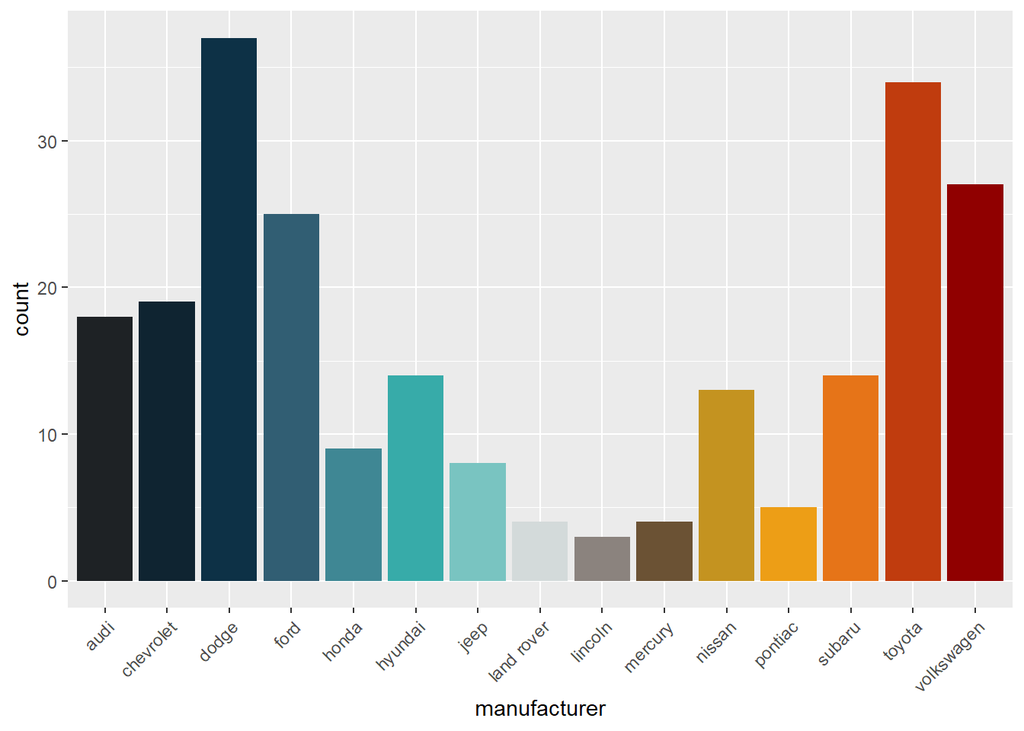

```r
ggplot(mpg, aes(manufacturer, fill = manufacturer)) +
    geom_bar() +
    theme(axis.text.x = element_text(angle = 45, hjust = 1)) +
    scale_fill_rjfranssen(palette = "all", guide = "none")
```

Finally, I want to be able to pull down my palette whereever I am, so I copied the above R code into `rjfranssen_col_pal.r` and pushed it to my [GitHub repo](https://github.com/rjfranssen/rjfranssen). I can read it down using `devtools` as an [r file](https://stackoverflow.com/questions/35720660/how-to-use-an-r-script-from-github) or as a [gist](https://gist.github.com/jtoll/4041987). [(devtools cheatsheet)](https://rstudio.com/wp-content/uploads/2015/03/devtools-cheatsheet.pdf)

```r
library(devtools)
source_url("https://raw.githubusercontent.com/rjfranssen/rjfranssen/main/utils/rjfranssen_col_pal.r")
```